# Individual 2 Lab 3

Andrew Sundberg

February 19, 2019

## R Markdown

```r
data(happy, package="productplots")
head(happy)
```

```
##   id         happy year age    sex       marital         degree
## 1  1 not too happy 1972  23 female never married       bachelor
## 2  2 not too happy 1972  70   male       married lt high school
## 3  3  pretty happy 1972  48 female       married    high school
## 4  4 not too happy 1972  27 female       married       bachelor
## 5  5  pretty happy 1972  61 female       married    high school
## 6  6  pretty happy 1972  26   male never married    high school
##         finrela    health wtssall
## 1       average      good  0.4446
## 2 above average      fair  0.8893
## 3       average excellent  0.8893
## 4       average      good  0.8893
## 5 above average      good  0.8893
## 6 above average      good  0.4446
```

```r
setwd("C:/Users/Andrew Sundberg/Documents/DS202/ds202_lab3")
HAPPY <- readRDS("HAPPY.rds")
head(HAPPY)
```

```
##           HAPPY YEAR AGE    SEX       MARITAL         DEGREE       FINRELA
## 1 NOT TOO HAPPY 1972  23 FEMALE NEVER MARRIED       BACHELOR       AVERAGE
## 2 NOT TOO HAPPY 1972  70   MALE       MARRIED LT HIGH SCHOOL ABOVE AVERAGE
## 3  PRETTY HAPPY 1972  48 FEMALE       MARRIED    HIGH SCHOOL       AVERAGE
## 4 NOT TOO HAPPY 1972  27 FEMALE       MARRIED       BACHELOR       AVERAGE
## 5  PRETTY HAPPY 1972  61 FEMALE       MARRIED    HIGH SCHOOL ABOVE AVERAGE
## 6  PRETTY HAPPY 1972  26   MALE NEVER MARRIED    HIGH SCHOOL ABOVE AVERAGE
##      HEALTH WTSSALL          PARTYID POLVIEWS
## 1      GOOD  0.4446     IND,NEAR DEM      IAP
## 2      FAIR  0.8893 NOT STR DEMOCRAT      IAP
## 3 EXCELLENT  0.8893      INDEPENDENT      IAP
## 4      GOOD  0.8893 NOT STR DEMOCRAT      IAP
## 5      GOOD  0.8893  STRONG DEMOCRAT      IAP
## 6      GOOD  0.4446     IND,NEAR DEM      IAP
```

```r
library(ggplot2)
```

```r
HAPPY[HAPPY == 'IAP' | HAPPY == 'DK'] = NA
```

2. & 3.

```r
HAPPY1 = as.character(HAPPY$HAPPY)
HAPPY$HAPPY <-factor(HAPPY1)

SEX1 = as.character(HAPPY$SEX)
SEX2 = factor(SEX1)
HAPPY$SEX = SEX2

MARITAL1 = as.character(HAPPY$MARITAL)
MARITAL2 = factor(MARITAL1, c('NEVER MARRIED', 'MARRIED', 'SEPARATED', 'DIVORCED', 'WIDOWED'))
HAPPY$MARITAL <- MARITAL2

DEGREE1 = as.character(HAPPY$DEGREE)
DEGREE2 = factor(DEGREE1, c('LT HIGH SCHOOL', 'HIGH SCHOOL', 'JUNIOR COLLEGE', 'BACHELOR', 'GRADUATE'))
HAPPY$DEGREE = DEGREE2

FINRELA1 = as.character(HAPPY$FINRELA)
FINRELA2 = factor(FINRELA1, c('FAR BELOW AVERAGE', 'BELOW AVERAGE', 'AVERAGE', 'ABOVE AVERAGE', 'FAR ABOVE AVERAGE'))
HAPPY$FINRELA = FINRELA2

HEALTH1 = as.character(HAPPY$HEALTH)
HEALTH2 = factor(HEALTH1, c('POOR', 'FAIR', 'GOOD', 'EXCELLENT'))
HAPPY$HEALTH = HEALTH2

PARTY1 = as.character(HAPPY$PARTYID)
PARTY2 = factor(PARTY1, c('STRONG DEMOCRAT', 'NOT STR DEMOCRAT', 'IND,NEAR DEM', 'INDEPENDENT', 'IND,NEAR REP', 'NOT STR REPUBLICAN', 'STRONG REPUBLICAN', 'OTHER PARTY'))
HAPPY$PARTYID = PARTY2

HAPPY[HAPPY =='89 OR OLDER'] <- '89'

HAPPY$AGE = as.numeric(HAPPY$AGE)
str(HAPPY)
```

```
## 'data.frame':    62466 obs. of  11 variables:
##  $ HAPPY   : Factor w/ 3 levels "NOT TOO HAPPY",..: 1 1 2 1 2 2 1 1 2 2 ...
##  $ YEAR    : int  1972 1972 1972 1972 1972 1972 1972 1972 1972 1972 ...
##  $ AGE     : num  23 70 48 27 61 26 28 27 21 30 ...
##  $ SEX     : Factor w/ 2 levels "FEMALE","MALE": 1 2 1 1 1 2 2 2 1 1 ...
##  $ MARITAL : Factor w/ 5 levels "NEVER MARRIED",..: 1 2 2 2 2 1 4 1 1 2 ...
##  $ DEGREE  : Factor w/ 5 levels "LT HIGH SCHOOL",..: 4 1 2 4 2 2 2 4 2 2 ...
##  $ FINRELA : Factor w/ 5 levels "FAR BELOW AVERAGE",..: 3 4 3 3 4 4 4 3 3 2 ...
##  $ HEALTH  : Factor w/ 4 levels "POOR","FAIR",..: 3 2 4 3 3 3 4 3 4 2 ...
##  $ WTSSALL : num  0.445 0.889 0.889 0.889 0.889 ...
##  $ PARTYID : Factor w/ 8 levels "STRONG DEMOCRAT",..: 3 2 4 2 1 3 3 3 1 1 ...
##  $ POLVIEWS: chr  NA NA NA NA ...
```

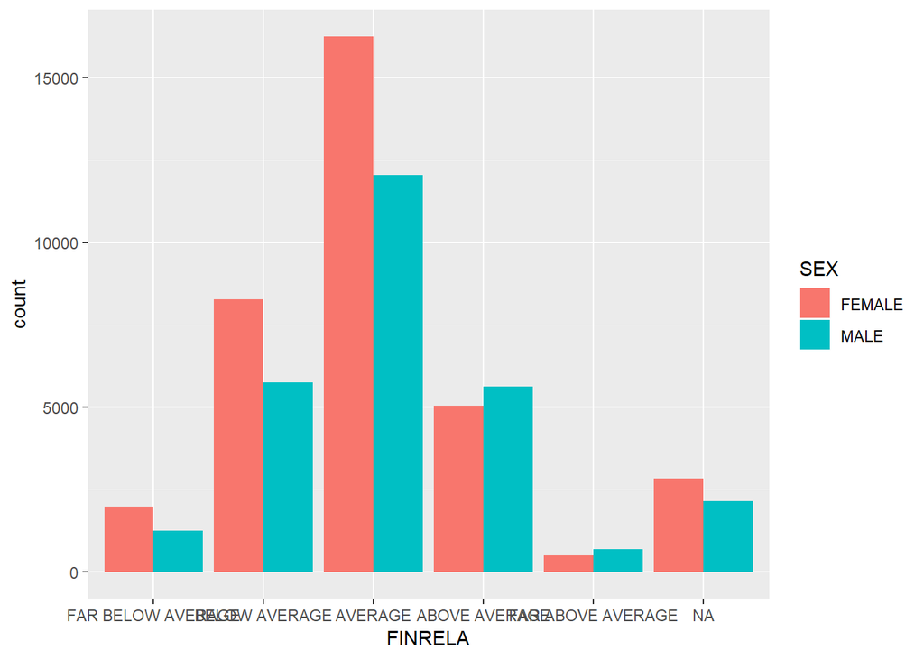

```r
ggplot(HAPPY, aes(x = FINRELA, fill = SEX)) + geom_bar(position = 'dodge')
```

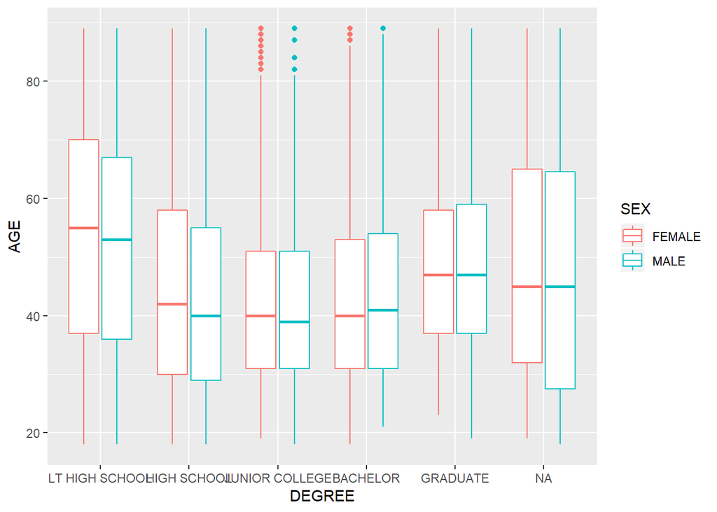

```r
ggplot(HAPPY, aes(x = DEGREE, y = AGE, color = SEX)) + geom_boxplot()
```

In the bar plot looking at the Income level divided into the two genders, there appears to be more females on the below average side of the graph. If you look at the below average column, there are more females in that financial status compared to the males. As for the the above average and far above average columns, there are more males in both of the columns.

In the box plot, the Light High School group has a much larger mean value than the rest of the degree types. The junior college and bachelor degrees appear to have the smalles mean age values. I would interpret that older people didn’t go to college but now younger people are, so the mean age is going down.

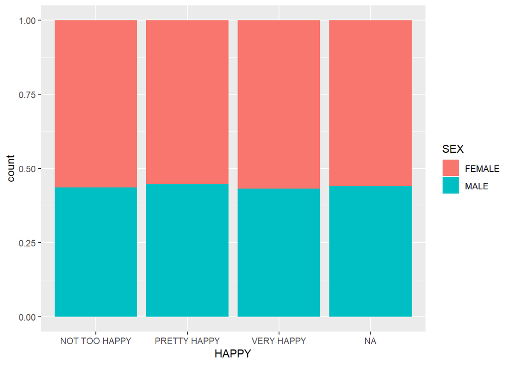

```r
ggplot(HAPPY, aes(x = HAPPY, fill = SEX)) + geom_bar(position = 'fill')
```

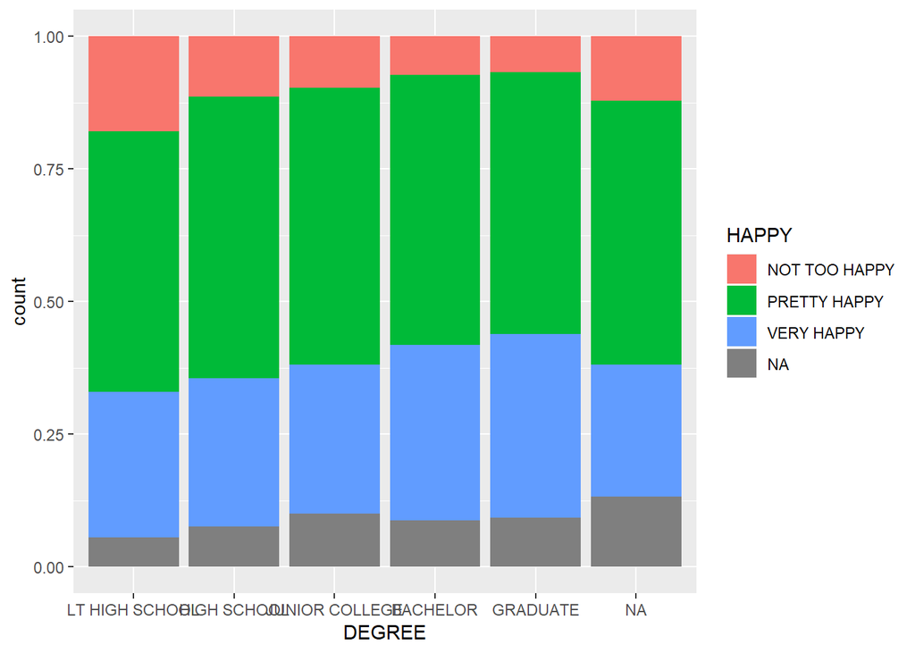

```r
ggplot(HAPPY, aes(x = DEGREE, fill = HAPPY)) + geom_bar(position = 'fill')
```

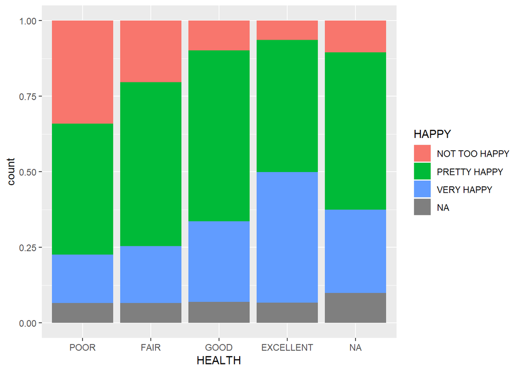

```r
ggplot(HAPPY, aes(x = HEALTH, fill = HAPPY)) + geom_bar(position = 'fill')
```

It appears that gender does not significantly tell the level happiness of a person. The chart shows basically the same proporion of men and women in every column. It appears that the degree a person has does affect their happiness. As you go from Light High School to Graduate you can see the red “Not too Happy” section getting smaller. Same thing for the relationship between health and happiness. As you go from Poor to Excellent on the health scale, you can see the Not too Happy proportion get smaller.

I learned that gender does not determine happiness. Also that health and level of education really help someone be happy.